# v1.14

[figure not shown]

- General Stats
- QualiMap
  - Coverage histogram
  - Cumulative genome coverage
  - Insert size histogram
  - GC content distribution

Toolbox

### MultiQC Toolbox

#### Export Plots

**Images**

**Data**

Download the raw data used to create the plots in this report below:

Note that additional data was saved in `multiqc_data` when this report was generated.

##### Choose Plots

If you use plots from MultiQC in a publication or presentation, please cite:

> **MultiQC: Summarize analysis results for multiple tools and samples in a single report**  
> *Philip Ewels, Måns Magnusson, Sverker Lundin and Max Käller*  
> Bioinformatics (2016)  
> doi: 10.1093/bioinformatics/btw354  
> PMID: 27312411

#### Tool Citations

Please remember to cite the tools that you use in your analysis.

To help with this, you can download publication details of the tools mentioned in this report:

#### About MultiQC

This report was generated using MultiQC, version 1.14

You can see a YouTube video describing how to use MultiQC reports here: [https://youtu.be/qPbIlO_KWN0](https://youtu.be/qPbIlO_KWN0?list=PLIA2-lqNuhvFGAsB92N0v7Qi5xCxCNsYM)

For more information about MultiQC, including other videos and extensive documentation, please visit [http://multiqc.info](http://multiqc.info/?ref=mqc_report)

You can report bugs, suggest improvements and find the source code for MultiQC on GitHub: https://github.com/ewels/MultiQC

MultiQC is published in Bioinformatics:

> **MultiQC: Summarize analysis results for multiple tools and samples in a single report**  
> *Philip Ewels, Måns Magnusson, Sverker Lundin and Max Käller*  
> Bioinformatics (2016)  
> doi: 10.1093/bioinformatics/btw354  
> PMID: 27312411

[figure not shown]

A modular tool to aggregate results from bioinformatics analyses across many samples into a single report.

Report generated on 2023-07-26, 03:10 CDT based on data in: `/media/Second_stor/wasif/WK_Rprojects/RP_230718_Taste_Genes_Analysis_1/MultiQC_Results/marked_duplicates_bam`

## General Statistics

Showing <sup>384</sup>/<sub>384</sub> rows and <sup>6</sup>/<sub>13</sub> columns.

| Sample Name | % GC | Ins. size | ≥ 1X | ≥ 5X | ≥ 10X | ≥ 30X | ≥ 50X | Median cov | Mean cov | % Aligned | M Aligned | M Total reads | Error rate |
| --- | --- | --- | --- | --- | --- | --- | --- | --- | --- | --- | --- | --- | --- |
| BS_006_marked_duplicates | 47% | 244 | 0.0% | 0.0% | 0.0% | 0.0% | 0.0% | 0.0X | 0.1X | 99.4% | 1.8 | 1.8 | 0.74% |
| BS_008_marked_duplicates | 49% | 270 | 0.0% | 0.0% | 0.0% | 0.0% | 0.0% | 0.0X | 0.1X | 99.4% | 1.7 | 1.7 | 0.84% |
| BS_014_marked_duplicates | 48% | 270 | 0.0% | 0.0% | 0.0% | 0.0% | 0.0% | 0.0X | 0.4X | 99.4% | 5.1 | 5.1 | 0.77% |
| BS_026_marked_duplicates | 47% | 240 | 0.0% | 0.0% | 0.0% | 0.0% | 0.0% | 0.0X | 0.1X | 99.4% | 1.4 | 1.4 | 0.76% |
| BS_027_marked_duplicates | 47% | 250 | 0.0% | 0.0% | 0.0% | 0.0% | 0.0% | 0.0X | 0.1X | 99.5% | 1.7 | 1.7 | 0.78% |
| BS_028_marked_duplicates | 48% | 270 | 0.0% | 0.0% | 0.0% | 0.0% | 0.0% | 0.0X | 0.2X | 99.3% | 2.4 | 2.4 | 0.87% |
| BS_029_marked_duplicates | 48% | 253 | 0.0% | 0.0% | 0.0% | 0.0% | 0.0% | 0.0X | 0.0X | 99.2% | 0.0 | 0.0 | 0.80% |
| BS_031_marked_duplicates | 47% | 272 | 0.0% | 0.0% | 0.0% | 0.0% | 0.0% | 0.0X | 0.0X | 99.5% | 0.2 | 0.2 | 0.76% |
| BS_033_marked_duplicates | 48% | 263 | 0.0% | 0.0% | 0.0% | 0.0% | 0.0% | 0.0X | 0.2X | 99.5% | 3.3 | 3.3 | 0.77% |
| BS_034_marked_duplicates | 49% | 272 | 0.0% | 0.0% | 0.0% | 0.0% | 0.0% | 0.0X | 0.3X | 99.4% | 3.8 | 3.8 | 0.81% |
| BS_036_marked_duplicates | 47% | 241 | 0.0% | 0.0% | 0.0% | 0.0% | 0.0% | 0.0X | 0.1X | 99.4% | 1.4 | 1.4 | 0.75% |
| BS_038_marked_duplicates | 48% | 258 | 0.0% | 0.0% | 0.0% | 0.0% | 0.0% | 0.0X | 0.2X | 99.4% | 2.6 | 2.6 | 0.77% |
| BS_040_marked_duplicates | 48% | 270 | 0.0% | 0.0% | 0.0% | 0.0% | 0.0% | 0.0X | 0.2X | 99.4% | 2.5 | 2.5 | 0.78% |
| BS_042_marked_duplicates | 49% | 240 | 0.0% | 0.0% | 0.0% | 0.0% | 0.0% | 0.0X | 0.1X | 99.4% | 0.9 | 0.9 | 0.81% |
| BS_043_marked_duplicates | 48% | 270 | 0.0% | 0.0% | 0.0% | 0.0% | 0.0% | 0.0X | 0.1X | 99.4% | 1.7 | 1.7 | 0.79% |
| BS_044_marked_duplicates | 48% | 272 | 0.0% | 0.0% | 0.0% | 0.0% | 0.0% | 0.0X | 0.3X | 99.4% | 4.2 | 4.2 | 0.95% |
| BS_049_marked_duplicates | 46% | 253 | 0.0% | 0.0% | 0.0% | 0.0% | 0.0% | 0.0X | 0.1X | 99.4% | 0.9 | 0.9 | 0.77% |
| BS_050_marked_duplicates | 48% | 270 | 0.0% | 0.0% | 0.0% | 0.0% | 0.0% | 0.0X | 0.2X | 99.5% | 2.5 | 2.5 | 0.84% |
| BS_051_marked_duplicates | 49% | 274 | 0.0% | 0.0% | 0.0% | 0.0% | 0.0% | 0.0X | 0.0X | 99.5% | 0.5 | 0.5 | 0.75% |
| BS_052_marked_duplicates | 49% | 267 | 0.0% | 0.0% | 0.0% | 0.0% | 0.0% | 0.0X | 0.2X | 99.5% | 2.9 | 2.9 | 0.79% |
| BS_053_marked_duplicates | 48% | 270 | 0.0% | 0.0% | 0.0% | 0.0% | 0.0% | 0.0X | 0.5X | 99.5% | 6.8 | 6.8 | 0.81% |
| BS_054_marked_duplicates | 49% | 271 | 0.0% | 0.0% | 0.0% | 0.0% | 0.0% | 0.0X | 0.3X | 99.3% | 4.7 | 4.7 | 0.82% |
| BS_055_marked_duplicates | 48% | 270 | 0.0% | 0.0% | 0.0% | 0.0% | 0.0% | 0.0X | 0.4X | 99.4% | 5.0 | 5.1 | 0.79% |
| BS_056_marked_duplicates | 49% | 270 | 0.0% | 0.0% | 0.0% | 0.0% | 0.0% | 0.0X | 0.3X | 99.4% | 3.9 | 3.9 | 0.79% |
| BS_058_marked_duplicates | 49% | 253 | 0.0% | 0.0% | 0.0% | 0.0% | 0.0% | 0.0X | 0.4X | 99.4% | 5.7 | 5.7 | 0.78% |
| BS_059_marked_duplicates | 48% | 271 | 0.0% | 0.0% | 0.0% | 0.0% | 0.0% | 0.0X | 0.3X | 99.4% | 4.3 | 4.3 | 0.82% |
| BS_063_marked_duplicates | 48% | 271 | 0.0% | 0.0% | 0.0% | 0.0% | 0.0% | 0.0X | 0.3X | 99.4% | 3.9 | 3.9 | 0.81% |
| BS_066_marked_duplicates | 48% | 272 | 0.0% | 0.0% | 0.0% | 0.0% | 0.0% | 0.0X | 0.5X | 99.4% | 7.2 | 7.2 | 0.83% |
| BS_068_marked_duplicates | 48% | 240 | 0.0% | 0.0% | 0.0% | 0.0% | 0.0% | 0.0X | 0.1X | 99.5% | 1.0 | 1.0 | 0.76% |
| BS_069_marked_duplicates | 48% | 274 | 0.0% | 0.0% | 0.0% | 0.0% | 0.0% | 0.0X | 0.3X | 99.4% | 4.5 | 4.6 | 0.81% |

[output cut: 354 more lines]

## QualiMap

[QualiMap](http://qualimap.bioinfo.cipf.es/) is a platform-independent application to facilitate the quality control of alignment sequencing data and its derivatives like feature counts.*DOI: 10.1093/bioinformatics/btv566; 10.1093/bioinformatics/bts503.*

### Coverage histogram

Distribution of the number of locations in the reference genome with a given depth of coverage.

For a set of DNA or RNA reads mapped to a reference sequence, such as a genome or transcriptome, the depth of coverage at a given base position is the number of high-quality reads that map to the reference at that position ([Sims et al. 2014](https://doi.org/10.1038/nrg3642)).

Bases of a reference sequence (y-axis) are groupped by their depth of coverage (*0×, 1×, …, N×*) (x-axis). This plot shows the frequency of coverage depths relative to the reference sequence for each read dataset, which provides an indirect measure of the level and variation of coverage depth in the corresponding sequenced sample.

If reads are randomly distributed across the reference sequence, this plot should resemble a Poisson distribution (Lander & Waterman 1988), with a peak indicating approximate depth of coverage, and more uniform coverage depth being reflected in a narrower spread. The optimal level of coverage depth depends on the aims of the experiment, though it should at minimum be sufficiently high to adequately address the biological question; greater uniformity of coverage is generally desirable, because it increases breadth of coverage for a given depth of coverage, allowing equivalent results to be achieved at a lower sequencing depth ([Sampson et al. 2011](https://doi.org/10.1002/gepi.20575); [Sims et al. 2014](https://doi.org/10.1038/nrg3642)). However, it is difficult to achieve uniform coverage depth in practice, due to biases introduced during sample preparation ([van Dijk et al. 2014](https://doi.org/10.1016/j.yexcr.2014.01.008)), sequencing ([Ross et al. 2013](https://doi.org/10.1186/gb-2013-14-5-r51)) and read mapping ([Sims et al. 2014](https://doi.org/10.1038/nrg3642)).

This plot may include a small peak for regions of the reference sequence with zero depth of coverage. Such regions may be absent from the given sample (due to a deletion or structural rearrangement), present in the sample but not successfully sequenced (due to bias in sequencing or preparation), or sequenced but not successfully mapped to the reference (due to the choice of mapping algorithm, the presence of repeat sequences, or mismatches caused by variants or sequencing errors). Related factors cause most datasets to contain some unmapped reads ([Sims et al. 2014](https://doi.org/10.1038/nrg3642)).

Flat image plot. Toolbox functions such as highlighting / hiding samples will not work (see the [docs](http://multiqc.info/docs/#flat--interactive-plots)).

[figure not shown]

### Cumulative genome coverage

Percentage of the reference genome with at least the given depth of coverage.

For a set of DNA or RNA reads mapped to a reference sequence, such as a genome or transcriptome, the depth of coverage at a given base position is the number of high-quality reads that map to the reference at that position, while the breadth of coverage is the fraction of the reference sequence to which reads have been mapped with at least a given depth of coverage ([Sims et al. 2014](https://doi.org/10.1038/nrg3642)).

Defining coverage breadth in terms of coverage depth is useful, because sequencing experiments typically require a specific minimum depth of coverage over the region of interest ([Sims et al. 2014](https://doi.org/10.1038/nrg3642)), so the extent of the reference sequence that is amenable to analysis is constrained to lie within regions that have sufficient depth. With inadequate sequencing breadth, it can be difficult to distinguish the absence of a biological feature (such as a gene) from a lack of data ([Green 2007](https://doi.org/10.1101/gr.7050807)).

For increasing coverage depths (*1×, 2×, …, N×*), coverage breadth is calculated as the percentage of the reference sequence that is covered by at least that number of reads, then plots coverage breadth (y-axis) against coverage depth (x-axis). This plot shows the relationship between sequencing depth and breadth for each read dataset, which can be used to gauge, for example, the likely effect of a minimum depth filter on the fraction of a genome available for analysis.

Flat image plot. Toolbox functions such as highlighting / hiding samples will not work (see the [docs](http://multiqc.info/docs/#flat--interactive-plots)).

[figure not shown]

### Insert size histogram

Distribution of estimated insert sizes of mapped reads.

To overcome limitations in the length of DNA or RNA sequencing reads, many sequencing instruments can produce two or more shorter reads from one longer fragment in which the relative position of reads is approximately known, such as paired-end or mate-pair reads ([Mardis 2013](https://doi.org/10.1146/annurev-anchem-062012-092628)). Such techniques can extend the reach of sequencing technology, allowing for more accurate placement of reads ([Reinert et al. 2015](https://doi.org/10.1146/annurev-genom-090413-025358)) and better resolution of repeat regions ([Reinert et al. 2015](https://doi.org/10.1146/annurev-genom-090413-025358)), as well as detection of structural variation ([Alkan et al. 2011](https://doi.org/10.1038/nrg2958)) and chimeric transcripts ([Maher et al. 2009](https://doi.org/10.1073/pnas.0904720106)).

All these methods assume that the approximate size of an insert is known. (Insert size can be defined as the length in bases of a sequenced DNA or RNA fragment, excluding technical sequences such as adapters, which are typically removed before alignment.) This plot allows for that assumption to be assessed. With the set of mapped fragments for a given sample, QualiMap groups the fragments by insert size, then plots the frequency of mapped fragments (y-axis) over a range of insert sizes (x-axis). In an ideal case, the distribution of fragment sizes for a sequencing library would culminate in a single peak indicating average insert size, with a narrow spread indicating highly consistent fragment lengths.

QualiMap calculates insert sizes as follows: for each fragment in which every read mapped successfully to the same reference sequence, it extracts the insert size from the `TLEN` field of the leftmost read (see the [Qualimap 2 documentation](http://qualimap.bioinfo.cipf.es/doc_html/index.html)), where the `TLEN` (or 'observed Template LENgth') field contains 'the number of bases from the leftmost mapped base to the rightmost mapped base' ([SAM format specification](https://samtools.github.io/hts-specs/)). Note that because it is defined in terms of alignment to a reference sequence, the value of the `TLEN` field may differ from the insert size due to factors such as alignment clipping, alignment errors, or structural variation or splicing in a gap between reads from the same fragment.

Flat image plot. Toolbox functions such as highlighting / hiding samples will not work (see the [docs](http://multiqc.info/docs/#flat--interactive-plots)).

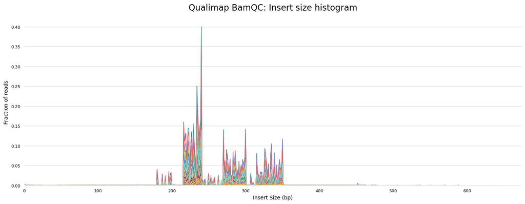

### GC content distribution

Each solid line represents the distribution of GC content of mapped reads for a given sample. The dotted line represents a pre-calculated GC distribution for the reference genome.

GC bias is the difference between the guanine-cytosine content (GC-content) of a set of sequencing reads and the GC-content of the DNA or RNA in the original sample. It is a well-known issue with sequencing systems, and may be introduced by PCR amplification, among other factors ([Benjamini & Speed 2012](https://doi.org/10.1093/nar/gks001); [Ross et al. 2013](https://doi.org/10.1186/gb-2013-14-5-r51)).

QualiMap calculates the GC-content of individual mapped reads, then groups those reads by their GC-content (*1%, 2%, …, 100%*), and plots the frequency of mapped reads (y-axis) at each level of GC-content (x-axis). This plot shows the GC-content distribution of mapped reads for each read dataset, which should ideally resemble that of the original sample. It can be useful to display the GC-content distribution of an appropriate reference sequence for comparison, and QualiMap has an option to do this (see the [Qualimap 2 documentation](http://qualimap.bioinfo.cipf.es/doc_html/index.html)).

Flat image plot. Toolbox functions such as highlighting / hiding samples will not work (see the [docs](http://multiqc.info/docs/#flat--interactive-plots)).

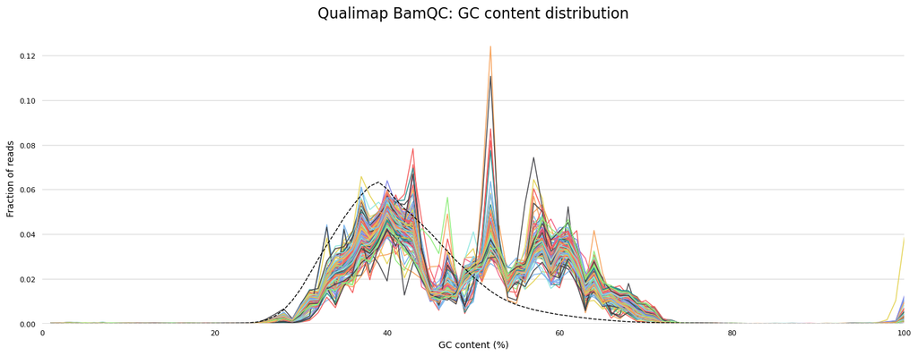

[figure not shown]

**[MultiQC v1.14](http://multiqc.info)** - Written by [Phil Ewels](http://phil.ewels.co.uk), available on [GitHub](https://github.com/ewels/MultiQC).

This report uses [HighCharts](http://www.highcharts.com/), [jQuery](https://jquery.com/), [jQuery UI](https://jqueryui.com/), [Bootstrap](http://getbootstrap.com/), FileSaver.js and [clipboard.js](https://clipboardjs.com/).